# Tarea Tercer Parcial

Natividad Oswaldo Pérez Medina

2025-05-24

# Capítulo 6

## Ejercicio 2

La serie $\{w_t\}$ es ruido blanco con media cero y varianza $\sigma_w^2$. Para los siguientes modelos de media móvil, encuentra la función de autocorrelación y determina si son invertibles. Además, simula 100 observaciones para cada modelo en R, compara los gráficos temporales de las series simuladas y comenta cómo podrían distinguirse las dos series.

- **a)** $x_t = w_t + \frac{1}{2}w_{t-1}$
- **b)** $x_t = w_t + 2w_{t-1}$

### Simulaciones

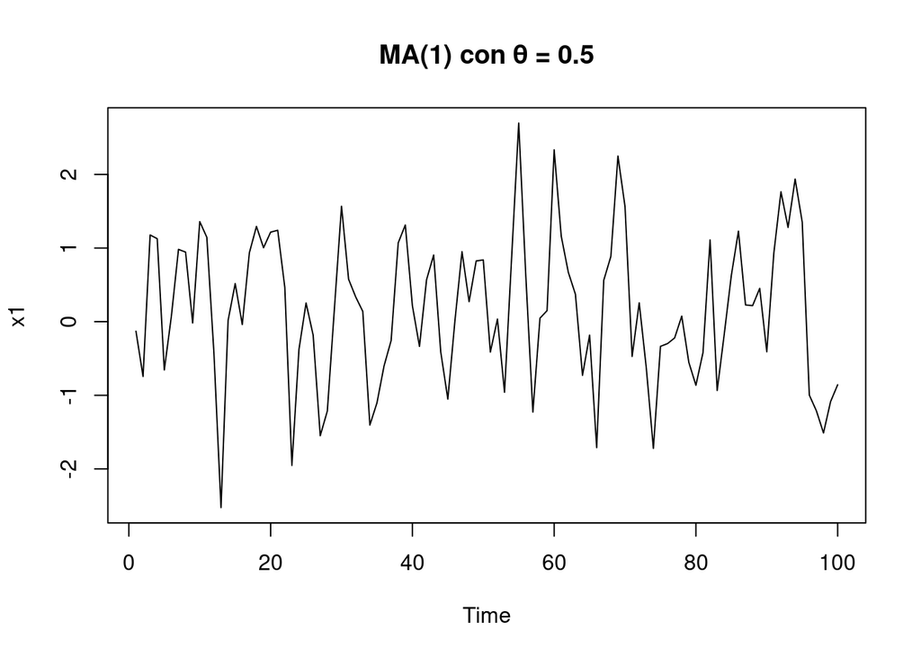

```r
set.seed(1)

# a) MA(1) con theta = 0.5
x1 <- arima.sim(model = list(ma = 0.5), n = 100)

# b) MA(1) con theta = 2
x2 <- arima.sim(model = list(ma = 2), n = 100)

# Gráficos temporales
plot.ts(x1, main = "MA(1) con θ = 0.5")
```

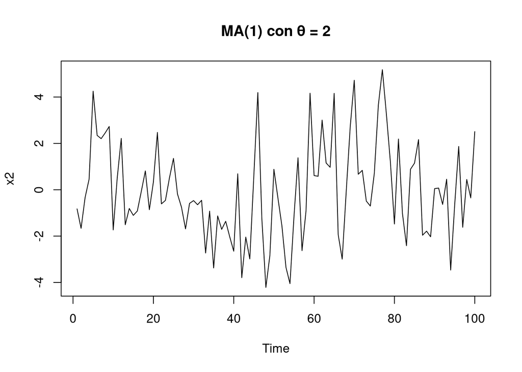

```r
plot.ts(x2, main = "MA(1) con θ = 2")
```

## Ejercicio 3

Escribe los siguientes modelos en notación ARMA$(p, q)$ y determina si son estacionarios y/o invertibles (donde $w_t$ es ruido blanco). En cada caso, revisa si hay redundancia de parámetros y asegúrate de que la notación ARMA$(p, q)$ esté expresada en su forma más simple.

- **a)** $x_t = x_{t-1} - \frac{1}{4}x_{t-2} + w_t + \frac{1}{2}w_{t-1}$
- **b)** $x_t = 2x_{t-1} - x_{t-2} + w_t$
- **c)** $x_t = \frac{3}{2}x_{t-1} - \frac{1}{2}x_{t-2} + w_t - \frac{1}{2}w_{t-1} + \frac{1}{4}w_{t-2}$
- **d)** $x_t = \frac{3}{2}x_{t-1} - \frac{1}{2}x_{t-2} + \frac{1}{2}w_{t-1}$
- **e)** $x_t = \frac{7}{10}x_{t-1} - \frac{1}{10}x_{t-2} + w_t - \frac{3}{2}w_{t-1}$
- **f)** $x_t = \frac{3}{2}x_{t-1} - \frac{1}{2}x_{t-2} + w_t - \frac{1}{3}w_{t-1} + \frac{1}{6}w_{t-2}$

## Ejercicio 4

- **a)** Ajusta un modelo de regresión adecuado a la serie de pasajeros aéreos. Comenta sobre el correlograma de los residuos del modelo de regresión ajustado.
- **b)** Ajusta un modelo ARMA$(p, q)$ a la serie de residuos del modelo de regresión ajustado, considerando valores de $p$ y $q$ no mayores a 2. Elige el mejor modelo con base en el AIC y comenta sobre su correlograma.
- **c)** Realiza una predicción del número de pasajeros que viajarán en la aerolínea durante el año 1961.

## Ejercicio 5

- **a)** Escribe una función en R que calcule la función de autocorrelación (Ecuación 6.13) para un proceso ARMA(1,1). Tu función debe recibir como parámetros los valores de $\alpha$ y $\beta$ correspondientes a los componentes AR y MA, respectivamente.
- **b)** Grafica la función de autocorrelación obtenida anteriormente para el caso $\alpha = 0.7$ y $\beta = -0.5$ para retardos (lags) de 0 a 20.
- **c)** Simula $n = 100$ valores del modelo ARMA(1,1) con $\alpha = 0.7$ y $\beta = -0.5$, y compara el correlograma muestral con el correlograma teórico graficado en la parte (b). Repite el análisis para $n = 1000$.

## Ejercicio 6

Sea $\{x_t : t = 1, \dots, n\}$ una serie temporal estacionaria con $E(x_t) = \mu$, $\text{Var}(x_t) = \sigma^2$, y $\text{Cor}(x_t, x_{t+k}) = \rho_k$. Usando la Ecuación (5.5) del Capítulo 5:

- **a)** Calcula $\text{Var}(\bar{x})$ cuando $\{x_t\}$ es el proceso MA(1) dado por $x_t = w_t + \frac{1}{2}w_{t-1}$.
- **b)** Calcula $\text{Var}(\bar{x})$ cuando $\{x_t\}$ es el proceso MA(1) dado por $x_t = w_t - \frac{1}{2}w_{t-1}$.
- **c)** Compara cada uno de los anteriores con la varianza de la media muestral obtenida para el caso de ruido blanco, donde se cumple que $\rho_k = 0$ ($k > 0$). De los tres modelos, ¿cuál tendría la estimación más precisa de $\mu$ basada en las varianzas de sus medias muestrales?
- **d)** Un ejemplo simulado que extrae la varianza de la media muestral para 100 series de ruido blanco gaussiano, cada una de longitud 20, se da por:

```r
set.seed(1)
m <- rep(0, 100)
for (i in 1:100) m[i] <- mean(rnorm(20))
var(m)
# [1] 0.0539
```

Para cada uno de los dos procesos MA(1), escribe el código en R que extrae la varianza de la media muestral de 100 realizaciones de longitud 20. Compara estos resultados con las varianzas calculadas en los incisos (a) y (b).

# Capítulo 7

En cada uno de los siguientes casos, $\{w_t\}$ es ruido blanco con media cero.

## Ejercicio 1

Identifica cada uno de los siguientes como modelos ARIMA específicos e indica si son o no estacionarios.

- **a)** $z_t = z_{t-1} - 0.25z_{t-2} + w_t + 0.5w_{t-1}$
- **b)** $z_t = 2z_{t-1} - z_{t-2} + w_t$
- **c)** $z_t = 0.5z_{t-1} + 0.5z_{t-2} + w_t - 0.5w_{t-1} + 0.25w_{t-2}$

## Ejercicio 2

Identifica los siguientes modelos como ciertos modelos ARIMA estacionales multiplicativos y determina si son invertibles y estacionarios.

- **a)** $z_t = 0.5z_{t-1} + z_{t-4} - 0.5z_{t-5} + w_t - 0.3w_{t-1}$
- **b)** $z_t = z_{t-1} + z_{t-12} - z_{t-13} + w_t - 0.5w_{t-1} - 0.5w_{t-12} + 0.25w_{t-13}$

## Ejercicio 3

Supón que $x_t = a + bt + w_t$. Define $y_t = \nabla x_t$.

- **a)** Demuestra que $x_t = x_0 + \sum_{i=1}^{t} y_i$ e identifica $x_0$.
- **b)** Supón ahora que se ajusta un modelo MA(1) a la serie $\{y_t\}$ y que el modelo ajustado es $y_t = b + w_t + \beta w_{t-1}$. Demuestra que una serie $\{x_t\}$ simulada a partir de este modelo tendrá una varianza creciente alrededor de la línea $a + bt$ a menos que $\beta$ sea exactamente igual a $-1$.

## Ejercicio 4

Descarga el archivo `osvisit`, cárgalo en R y realiza el siguiente análisis. Tu solución debe incluir comandos en R, gráficas y comentarios. Sea $x_t$ el número de visitantes en el tiempo $t$ (en meses) y $z_t = \ln(x_t)$.

- **a)** Comenta sobre las características principales en el correlograma de $\{z_t\}$.
- **b)** Ajusta un modelo ARIMA(1, 1, 0) a $\{z_t\}$, obteniendo el parámetro AR estimado y la desviación estándar de los residuos. Comenta sobre el correlograma de los residuos de este modelo ARIMA.
- **c)** Ajusta un modelo ARIMA estacional (1, 1, 0)(0, 1, 0)$_{12}$ a $\{z_t\}$ y grafica el correlograma de los residuos de este modelo. ¿Ha eliminado la diferenciación estacional el efecto estacional? Comenta.
- **d)** Elige el mejor modelo ARIMA estacional de entre los siguientes:
  - ARIMA(1, 1, 0)(1, 1, 0)$_{12}$
  - ARIMA(0, 1, 1)(0, 1, 1)$_{12}$
  - ARIMA(1, 1, 0)(0, 1, 1)$_{12}$
  - ARIMA(0, 1, 1)(1, 1, 0)$_{12}$
  - ARIMA(1, 1, 1)(0, 1, 1)$_{12}$
  - ARIMA(1, 1, 1)(1, 1, 0)$_{12}$
  - ARIMA(1, 1, 1)(0, 1, 0)$_{12}$

Basándote en el AIC, comenta sobre el correlograma de los residuos del mejor modelo.

- **e)** Expresa el mejor modelo ajustado en el inciso (d) en términos de $z_t$, los componentes de ruido blanco y el operador de rezago (backward shift operator) (puedes escribirlo a mano, no es necesario expandir todos los factores).
- **f)** Prueba los residuos del mejor modelo ARIMA estacional ajustado para determinar si son estacionarios.
- **g)** Pronostica el número de visitantes extranjeros para cada mes del año 1996, y el número total de visitantes esperados en 1996. **[Pista:** Para obtener los pronósticos, puedes usar el comando `predict()` en R para el modelo ARIMA estacional que seleccionaste, y sumar los pronósticos mensuales.]

## Ejercicio 5

Utiliza la función `get.best.arima` de la Sección §7.3.2 para obtener el modelo ARIMA$(p, d, q)(P, D, Q)_{12}$ que mejor se ajuste, considerando todos los valores $p, d, q, P, D, Q \leq 2$, al logaritmo de la serie de producción de chocolate en Australia.

- Verifica que el correlograma de los residuos del modelo seleccionado sea representativo de ruido blanco.
- Verifica también el correlograma de los residuos al cuadrado.
- Comenta los resultados obtenidos.